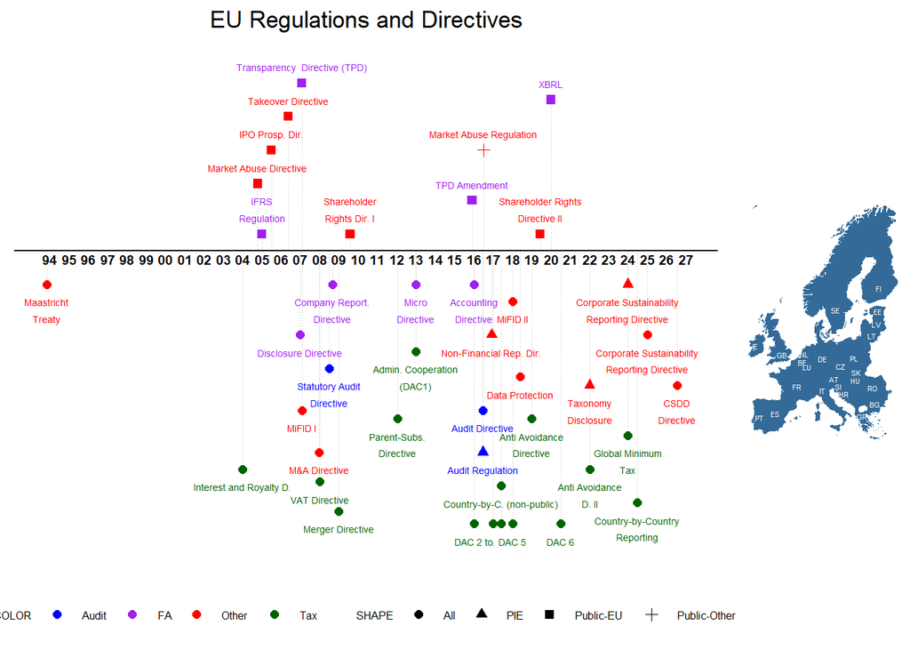

Notes: The graph depicts major regulatory changes that we identified via an extensive literature search, an online survey of mentioned authors, and other sources. Please note that the graph does not include all possible regulatory changes, e.g. minor revisions to local GAAP or tax rate changes below 3% are not included. The dates of EU Directives are based on the official transposition deadlines unless denoted with a *, in which case we included the entry-to-force date as identified in the literature. For more information, please go to [Labro and Pierk (2023)](http://www.eu-regulations.com/Labro_Pierk_2023.pdf). We kindly ask that you cite the paper if you use the information on this website in your research project. Do you have comments or see anything missing? Please email us!

## Regulations, Publications, Further Graphs

The tab ‘Regulations’ includes links to the regulations, gives short descriptions, and provides selective papers for further reading. If the regulation is a national transposition of an EU Directive, the link to the Directive is given. The tab ‘Number of Regulations’ shows graphically the number of regulations 8 years around the respective year (-4,-3,-2,-1,0,+1,+2,+3). The tab ‘Number of Categories” shows graphically the number of different categories 8 years around the respective year (-4,-3,-2,-1,0,+1,+2,+3). The tab ’Publications’ shows all publications that include the countries’ names and variations thereof in the title, abstract, or keywords. Similarly, the tab ‘SSRN’ shows papers of the SSRN Accouning Research Network that include the countries’ names and variations.

### Regulations

|  | Date | Milestones | Applies_to | Category | Description |
| --- | --- | --- | --- | --- | --- |
| 1 | 1993-11-01 | Maastricht Treaty | Public-EU | FA | Maastricht Treaty: Signed 'Treaty on European Union". |
| 2 | 2004-01-01 | Interest and Royalty D. | All Firms | Tax | Directive 2003/49: Exemption from tax on interest and royalty payments within multinationals within the EU. See also: Featherstone, Gaut, Rowley and Fabre 2005 |
| 3 | 2004-10-12 | Market Abuse Directive | Public-EU | Other | Directive 2003/6/EC: "The Market Abuse Directive (2003/6/EC) aims to prevent insider trading and market manipulation. It contains three key elements: (1) disclosure rules designed to reduce the scope … |
| 4 | 2005-01-01 | IFRS Regulation | Public-EU | FA | Regulation 1606/2002: Firms listed on EU-regulated markets are required to use the International Financial Reporting Standards (IFRS) for their consolidated financial statements. Firms that use US GAA… |
| 5 | 2005-07-01 | IPO Prospectus Directive | Public-EU | Other | Directive 2003/71/EC: Increased IPO prospectus disclosure. See also: Byard, Darrough, and Suh 2021 |
| 6 | 2006-05-20 | Takeover Directive | Public-EU | Other | Directive 2004/25/EC: The Directive 'lays down measures to coordinate the laws, regulations, administrative provisions, codes of practice […] relating to takeover bids for the securities of companies … |
| 7 | 2006-12-30 | Disclosure Directive | All Firms | FA | Directive 2003/58/EC: Introduction of penalties for non-disclosure of financial statements. See also: Bernard 2016 |
| 8 | 2007-01-20 | Transparency Directive (TPD) | Public-EU | FA | Directive 2004/109/EC: Harmonization of transparency requirements for firms listed on EU-regulated markets. Introduction of mandatory quarterly reporting for publicly listed firms (at least Interim Ma… |
| 9 | 2007-01-31 | MiFID I | All Firms | Other | Directive 2004/39/EC: The Markets in Financial Instruments Directive (MiFID I) came into force on 1 November 2007 and created a single European financial service market. For example, financial service… |
| 10 | 2007-12-14 | M&A Directive | All Firms | Other | Directive 2005/56/EC: Introduced a harmonizing legal basis within the European Union for cross-border mergers |

[output cut: 33 more lines]

### Number of Regulations

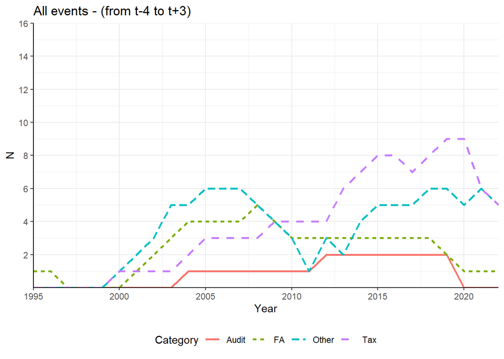

### Number of Categories

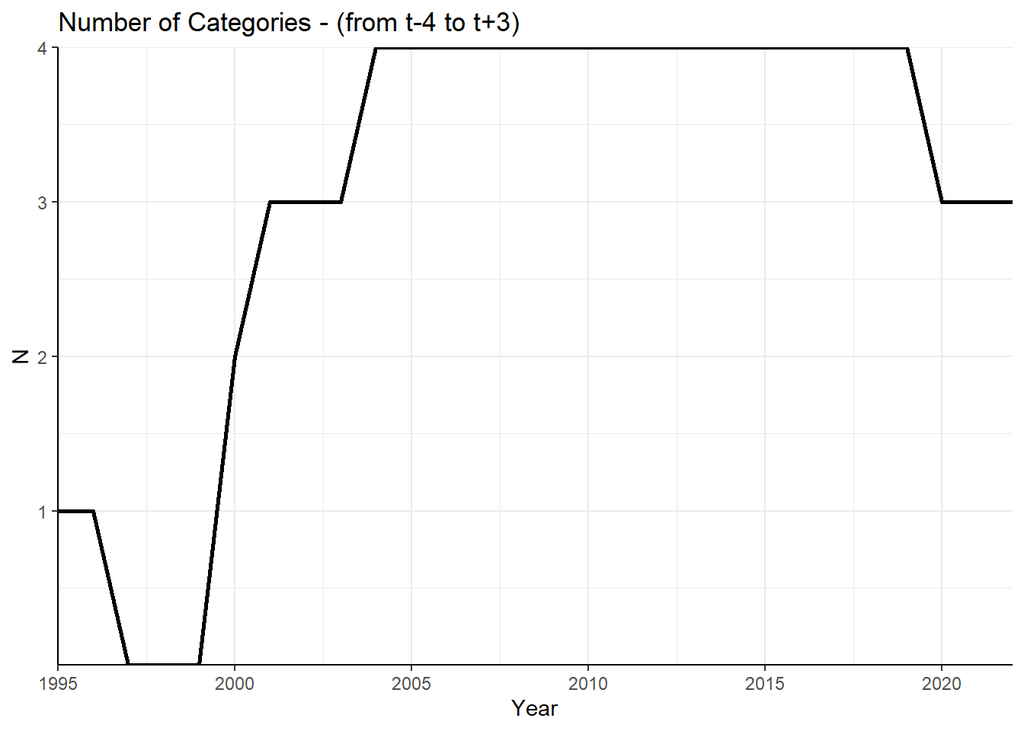

### Publications

|  | authors | title | year | journal |
| --- | --- | --- | --- | --- |
| 1 | Adams M., Baker P.L. | does boardroom nationality affect the performance of uk insurers? | 2021 | British Accounting Review |
| 2 | Agarwal N., Chakraverty A. | growth opportunities, information asymmetry, and dividend payout: evidence from mandatory ifrs adoption | 2021 | European Accounting Review |
| 3 | Aghazadeh S., Brown J.O., Guichard L., Hoang K. | persuasion in auditing: a review through the lens of the communication-persuasion matrix | 2021 | European Accounting Review |
| 4 | Agostini M., Costa E., Korca B. | non-financial disclosure and corporate financial performance under directive 2014/95/eu: evidence from italian listed companies | 2021 | Accounting in Europe |
| 5 | Al Mamun M.D., Balachandran B., Duong H.N., Gul F.A. | are corporate general counsels in top management effective monitors? evidence from stock price crash risk | 2021 | European Accounting Review |
| 6 | Amel-Zadeh A., Glaum M., Sellhorn T. | empirical goodwill research: insights, issues, and implications for standard setting and future research | 2021 | European Accounting Review |
| 7 | Aranda C., Arellano J., Dávila A. | budgeting in public organizations: the influence of managerial and political aspects | 2021 | European Accounting Review |
| 8 | Astolfi P. | did the international financial reporting standards increase the audit expectation gap? an exploratory study | 2021 | Accounting in Europe |
| 9 | Azizan S., Shailer G. | does corporate citizenship influence auditors’ perceptions of the credibility of management in relation to financial reports? | 2021 | European Accounting Review |
| 10 | Balakrishnan K., De George E.T., Ertan A., Scobie H. | economic consequences of mandatory auditor reporting to bank regulators | 2021 | Journal of Accounting and Economics |

[output cut: 1081 more lines]

### SSRN

|  | authors | title | Posted | Revised |
| --- | --- | --- | --- | --- |
| 1 | Alexander Schopper and Patrick Raschner | cryptocurrencies on a bank’s balance sheet | 2021-12-30 |  |
| 2 | Gabor Koltay, Szabolcs Lorincz and Tommaso M. Valletti | concentration and competition: evidence from europe and implications for policy | 2021-12-28 |  |
| 3 | Matthias Breuer, Christian Leuz and Steven Vanhaverbeke | reporting regulation and corporate innovation | 2021-12-22 |  |
| 4 | Mark J. Roe | looking for the economy-wide effects of stock market short-termism | 2021-12-22 |  |
| 5 | Zehra G. Kavame Eroglu | global adoption of ifrs as an example of international financial law making | 2021-12-20 |  |
| 6 | Philippe Maupas and Luc Paugam | regulatory arbitrage on narrative steroids: the case of spacs | 2021-12-20 |  |
| 7 | Massimiliano Bonacchi, Fabio Ciaponi, Antonio Marra and Ron Shalev | the unintended consequences of accounting-based regulation: real effects on european football players transfer market | 2021-12-06 |  |
| 8 | Hyun A. Hong, Mingyi Hung and Gerald J. Lobo | response to “re-examining the impact of mandatory ifrs adoption on ipo underpricing” by byard, darrough, and suh (2021) | 2021-12-06 |  |
| 9 | Andrea Albarea, Michele Bernasconi, Anna Marenzi and Dino Rizzi | tax evasion, behavioral microsimulation models and flat-rate tax reforms. analysis for italy | 2021-11-24 |  |
| 10 | Jesper Haga, Kenneth Högholm and Dennis Sundvik | peer firms’ reporting frequency and stock price synchronicity: european evidence | 2021-11-24 |  |

[output cut: 166 more lines]